# Cyclistic Case Study

Oluwatunmise Ayinde

2022-05-17

## Background for this Activity

In this activity, I will review a scenario, and focus on manipulating and changing real data in R. I will learn more about functions I can use to manipulate my data, use statistical summaries to explore my data, and gain initial insights for stakeholders.

Throughout this activity, i will also have the opportunity to practice writing my own code by making changes to the code chunks yourself.

## The Scenario

In 2016, Cyclistic launched a successful bike-share offering. Since then, the program has grown to a fleet of 5,824 bicycles that are geotracked and locked into a network of 692 stations across Chicago. The bikes can be unlocked from one station and returned to any other station in the system anytime.

There are two types of cyclists, those who purchase casual tickets and those purchase annual memberships. The marketing team believes that maximizing the number of annual members will be key to future growth. Rather than creating a marketing campaign that targets all-new-customers, there is a very good chance to convert casual riders into members.

## Problem

What is the most effective marketing strategy of converting Cyclistic’s casual riders to annual memberships? * How do annual members and casual riders use Cyclistic’s bikes differently?

## NOTE

This project was initially started with excel. Excel was used to clean the data, and to calculate the ride length of each trip and also to get the weekdays each trip started. Duplicate columns were removed, white spaces trimmed and all other basic data cleaning processes.

## Step 1: LOAD PACKAGES

```r
install.packages("tidyverse", repos = "http://cran.us.r-project.org")
install.packages("janitor", repos = "http://cran.us.r-project.org")
install.packages("skimr", repos = "http://cran.us.r-project.org")
install.packages("lubridate", repos = "http://cran.us.r-project.org")
library(tidyverse)
library(janitor)
library(skimr)
library(lubridate)
```

## Step 2: READ ALL CSV FILES

```r
df1 <-read_csv("202101-divvy-tripdata.csv")
df2 <-read_csv("202102-divvy-tripdata.csv")
df3 <-read_csv("202103-divvy-tripdata.csv")
df4 <-read_csv("202104-divvy-tripdata.csv")
df5 <-read_csv("202105-divvy-tripdata.csv")
df6 <-read_csv("202106-divvy-tripdata.csv")
df7 <-read_csv("202107-divvy-tripdata.csv")
df8 <-read_csv("202108-divvy-tripdata.csv")
df9 <-read_csv("202109-divvy-tripdata.csv")
df10 <-read_csv("202110-divvy-tripdata.csv")
df11 <-read_csv("202111-divvy-tripdata.csv")
df12 <-read_csv("202112-divvy-tripdata.csv")
View(df1)
```

## Step 3: PREVIEW THE DATA STRUCTURE OF THE MONTHLY DATA

This is done using the “str()” fuction

```r
str(df1)
```

```
## spec_tbl_df [96,834 × 15] (S3: spec_tbl_df/tbl_df/tbl/data.frame)
##  $ ride_id           : chr [1:96834] "E19E6F1B8D4C42ED" "DC88F20C2C55F27F" "EC45C94683FE3F27" "4FA453A75AE377DB" ...
##  $ rideable_type     : chr [1:96834] "electric_bike" "electric_bike" "electric_bike" "electric_bike" ...
##  $ started_at        : chr [1:96834] "2021-01-23 16:14:19" "2021-01-27 18:43:08" "2021-01-21 22:35:54" "2021-01-07 13:31:13" ...
##  $ ended_at          : chr [1:96834] "2021-01-23 16:24:44" "2021-01-27 18:47:12" "2021-01-21 22:37:14" "2021-01-07 13:42:55" ...
##  $ start_station_name: chr [1:96834] "California Ave & Cortez St" "California Ave & Cortez St" "California Ave & Cortez St" "California Ave & Cortez St" ...
##  $ start_station_id  : chr [1:96834] "17660" "17660" "17660" "17660" ...
##  $ end_station_name  : chr [1:96834] NA NA NA NA ...
##  $ end_station_id    : chr [1:96834] NA NA NA NA ...
##  $ start_lat         : num [1:96834] 41.9 41.9 41.9 41.9 41.9 ...
##  $ start_lng         : num [1:96834] -87.7 -87.7 -87.7 -87.7 -87.7 ...
##  $ end_lat           : num [1:96834] 41.9 41.9 41.9 41.9 41.9 ...
##  $ end_lng           : num [1:96834] -87.7 -87.7 -87.7 -87.7 -87.7 ...
##  $ member_casual     : chr [1:96834] "member" "member" "member" "member" ...
##  $ ride_length       : 'hms' num [1:96834] 00:10:25 00:04:04 00:01:20 00:11:42 ...
##   ..- attr(*, "units")= chr "secs"
##  $ day_of_week       : num [1:96834] 7 4 5 5 7 7 2 5 7 1 ...
##  - attr(*, "spec")=
##   .. cols(
##   ..   ride_id = col_character(),
##   ..   rideable_type = col_character(),
##   ..   started_at = col_character(),
##   ..   ended_at = col_character(),
##   ..   start_station_name = col_character(),
##   ..   start_station_id = col_character(),
##   ..   end_station_name = col_character(),
##   ..   end_station_id = col_character(),
##   ..   start_lat = col_double(),
##   ..   start_lng = col_double(),
##   ..   end_lat = col_double(),
##   ..   end_lng = col_double(),
##   ..   member_casual = col_character(),
##   ..   ride_length = col_time(format = ""),
##   ..   day_of_week = col_double()
##   .. )
##  - attr(*, "problems")=<externalptr>
```

```r
str(df2)
```

```
## spec_tbl_df [49,622 × 15] (S3: spec_tbl_df/tbl_df/tbl/data.frame)
##  $ ride_id           : chr [1:49622] "89E7AA6C29227EFF" "0FEFDE2603568365" "E6159D746B2DBB91" "B32D3199F1C2E75B" ...
##  $ rideable_type     : chr [1:49622] "classic_bike" "classic_bike" "electric_bike" "classic_bike" ...
##  $ started_at        : chr [1:49622] "2021-02-12 16:14:56" "2021-02-14 17:52:38" "2021-02-09 19:10:18" "2021-02-02 17:49:41" ...
##  $ ended_at          : chr [1:49622] "2021-02-12 16:21:43" "2021-02-14 18:12:09" "2021-02-09 19:19:10" "2021-02-02 17:54:06" ...
##  $ start_station_name: chr [1:49622] "Glenwood Ave & Touhy Ave" "Glenwood Ave & Touhy Ave" "Clark St & Lake St" "Wood St & Chicago Ave" ...
##  $ start_station_id  : chr [1:49622] "525" "525" "KA1503000012" "637" ...
##  $ end_station_name  : chr [1:49622] "Sheridan Rd & Columbia Ave" "Bosworth Ave & Howard St" "State St & Randolph St" "Honore St & Division St" ...
##  $ end_station_id    : chr [1:49622] "660" "16806" "TA1305000029" "TA1305000034" ...
##  $ start_lat         : num [1:49622] 42 42 41.9 41.9 41.8 ...
##  $ start_lng         : num [1:49622] -87.7 -87.7 -87.6 -87.7 -87.6 ...
##  $ end_lat           : num [1:49622] 42 42 41.9 41.9 41.8 ...
##  $ end_lng           : num [1:49622] -87.7 -87.7 -87.6 -87.7 -87.6 ...
##  $ member_casual     : chr [1:49622] "member" "casual" "member" "member" ...
##  $ ride_length       : 'hms' num [1:49622] 00:06:47 00:19:31 00:08:52 00:04:25 ...
##   ..- attr(*, "units")= chr "secs"
##  $ day_of_week       : num [1:49622] 6 1 3 3 3 4 2 5 7 7 ...
##  - attr(*, "spec")=
##   .. cols(
##   ..   ride_id = col_character(),
##   ..   rideable_type = col_character(),
##   ..   started_at = col_character(),
##   ..   ended_at = col_character(),
##   ..   start_station_name = col_character(),
##   ..   start_station_id = col_character(),
##   ..   end_station_name = col_character(),
##   ..   end_station_id = col_character(),
##   ..   start_lat = col_double(),
##   ..   start_lng = col_double(),
##   ..   end_lat = col_double(),
##   ..   end_lng = col_double(),
##   ..   member_casual = col_character(),
##   ..   ride_length = col_time(format = ""),
##   ..   day_of_week = col_double()
##   .. )
##  - attr(*, "problems")=<externalptr>
```

```r
str(df3)
```

```
## spec_tbl_df [228,496 × 15] (S3: spec_tbl_df/tbl_df/tbl/data.frame)
##  $ ride_id           : chr [1:228496] "CFA86D4455AA1030" "30D9DC61227D1AF3" "846D87A15682A284" "994D05AA75A168F2" ...
##  $ rideable_type     : chr [1:228496] "classic_bike" "classic_bike" "classic_bike" "classic_bike" ...
##  $ started_at        : chr [1:228496] "2021-03-16 8:32:30" "2021-03-28 1:26:28" "2021-03-11 21:17:29" "2021-03-11 13:26:42" ...
##  $ ended_at          : chr [1:228496] "2021-03-16 8:36:34" "2021-03-28 1:36:55" "2021-03-11 21:33:53" "2021-03-11 13:55:41" ...
##  $ start_station_name: chr [1:228496] "Humboldt Blvd & Armitage Ave" "Humboldt Blvd & Armitage Ave" "Shields Ave & 28th Pl" "Winthrop Ave & Lawrence Ave" ...
##  $ start_station_id  : chr [1:228496] "15651" "15651" "15443" "TA1308000021" ...
##  $ end_station_name  : chr [1:228496] "Stave St & Armitage Ave" "Central Park Ave & Bloomingdale Ave" "Halsted St & 35th St" "Broadway & Sheridan Rd" ...
##  $ end_station_id    : chr [1:228496] "13266" "18017" "TA1308000043" "13323" ...
##  $ start_lat         : num [1:228496] 41.9 41.9 41.8 42 42 ...
##  $ start_lng         : num [1:228496] -87.7 -87.7 -87.6 -87.7 -87.7 ...
##  $ end_lat           : num [1:228496] 41.9 41.9 41.8 42 42.1 ...
##  $ end_lng           : num [1:228496] -87.7 -87.7 -87.6 -87.6 -87.7 ...
##  $ member_casual     : chr [1:228496] "casual" "casual" "casual" "casual" ...
##  $ ride_length       : 'hms' num [1:228496] 00:04:04 00:10:27 00:16:24 00:28:59 ...
##   ..- attr(*, "units")= chr "secs"
##  $ day_of_week       : num [1:228496] 3 1 5 5 1 7 7 3 4 5 ...
##  - attr(*, "spec")=
##   .. cols(
##   ..   ride_id = col_character(),
##   ..   rideable_type = col_character(),
##   ..   started_at = col_character(),
##   ..   ended_at = col_character(),
##   ..   start_station_name = col_character(),
##   ..   start_station_id = col_character(),
##   ..   end_station_name = col_character(),
##   ..   end_station_id = col_character(),
##   ..   start_lat = col_double(),
##   ..   start_lng = col_double(),
##   ..   end_lat = col_double(),
##   ..   end_lng = col_double(),
##   ..   member_casual = col_character(),
##   ..   ride_length = col_time(format = ""),
##   ..   day_of_week = col_double()
##   .. )
##  - attr(*, "problems")=<externalptr>
```

```r
str(df4)
```

```
## spec_tbl_df [337,230 × 15] (S3: spec_tbl_df/tbl_df/tbl/data.frame)
##  $ ride_id           : chr [1:337230] "6C992BD37A98A63F" "1E0145613A209000" "E498E15508A80BAD" "1887262AD101C604" ...
##  $ rideable_type     : chr [1:337230] "classic_bike" "docked_bike" "docked_bike" "classic_bike" ...
##  $ started_at        : chr [1:337230] "4/12/2021 18:25" "4/27/2021 17:27" "4/3/2021 12:42" "4/17/2021 9:17" ...
##  $ ended_at          : chr [1:337230] "4/12/2021 18:56" "4/27/2021 18:31" "4/7/2021 11:40" "4/17/2021 9:42" ...
##  $ start_station_name: chr [1:337230] "State St & Pearson St" "Dorchester Ave & 49th St" "Loomis Blvd & 84th St" "Honore St & Division St" ...
##  $ start_station_id  : chr [1:337230] "TA1307000061" "KA1503000069" "20121" "TA1305000034" ...
##  $ end_station_name  : chr [1:337230] "Southport Ave & Waveland Ave" "Dorchester Ave & 49th St" "Loomis Blvd & 84th St" "Southport Ave & Waveland Ave" ...
##  $ end_station_id    : chr [1:337230] "13235" "KA1503000069" "20121" "13235" ...
##  $ start_lat         : num [1:337230] 41.9 41.8 41.7 41.9 41.7 ...
##  $ start_lng         : num [1:337230] -87.6 -87.6 -87.7 -87.7 -87.7 ...
##  $ end_lat           : num [1:337230] 41.9 41.8 41.7 41.9 41.7 ...
##  $ end_lng           : num [1:337230] -87.7 -87.6 -87.7 -87.7 -87.7 ...
##  $ member_casual     : chr [1:337230] "member" "casual" "casual" "member" ...
##  $ ride_length       : 'hms' num [1:337230] 00:31:19 01:04:18 94:57:39 00:25:06 ...
##   ..- attr(*, "units")= chr "secs"
##  $ day_of_week       : num [1:337230] 2 3 7 7 7 1 7 3 2 7 ...
##  - attr(*, "spec")=
##   .. cols(
##   ..   ride_id = col_character(),
##   ..   rideable_type = col_character(),
##   ..   started_at = col_character(),
##   ..   ended_at = col_character(),
##   ..   start_station_name = col_character(),
##   ..   start_station_id = col_character(),
##   ..   end_station_name = col_character(),
##   ..   end_station_id = col_character(),
##   ..   start_lat = col_double(),
##   ..   start_lng = col_double(),
##   ..   end_lat = col_double(),
##   ..   end_lng = col_double(),
##   ..   member_casual = col_character(),
##   ..   ride_length = col_time(format = ""),
##   ..   day_of_week = col_double()
##   .. )
##  - attr(*, "problems")=<externalptr>
```

```r
str(df5)
```

```
## spec_tbl_df [531,633 × 15] (S3: spec_tbl_df/tbl_df/tbl/data.frame)
##  $ ride_id           : chr [1:531633] "C809ED75D6160B2A" "DD59FDCE0ACACAF3" "0AB83CB88C43EFC2" "7881AC6D39110C60" ...
##  $ rideable_type     : chr [1:531633] "electric_bike" "electric_bike" "electric_bike" "electric_bike" ...
##  $ started_at        : chr [1:531633] "2021-05-30 11:58:15" "2021-05-30 11:29:14" "2021-05-30 14:24:01" "2021-05-30 14:25:51" ...
##  $ ended_at          : chr [1:531633] "2021-05-30 12:10:39" "2021-05-30 12:14:09" "2021-05-30 14:25:13" "2021-05-30 14:41:04" ...
##  $ start_station_name: chr [1:531633] NA NA NA NA ...
##  $ start_station_id  : chr [1:531633] NA NA NA NA ...
##  $ end_station_name  : chr [1:531633] NA NA NA NA ...
##  $ end_station_id    : chr [1:531633] NA NA NA NA ...
##  $ start_lat         : num [1:531633] 41.9 41.9 41.9 41.9 41.9 ...
##  $ start_lng         : num [1:531633] -87.6 -87.6 -87.7 -87.7 -87.7 ...
##  $ end_lat           : num [1:531633] 41.9 41.8 41.9 41.9 41.9 ...
##  $ end_lng           : num [1:531633] -87.6 -87.6 -87.7 -87.7 -87.7 ...
##  $ member_casual     : chr [1:531633] "casual" "casual" "casual" "casual" ...
##  $ ride_length       : 'hms' num [1:531633] 00:12:24 00:44:55 00:01:12 00:15:13 ...
##   ..- attr(*, "units")= chr "secs"
##  $ day_of_week       : num [1:531633] 1 1 1 1 1 1 1 4 4 3 ...
##  - attr(*, "spec")=
##   .. cols(
##   ..   ride_id = col_character(),
##   ..   rideable_type = col_character(),
##   ..   started_at = col_character(),
##   ..   ended_at = col_character(),
##   ..   start_station_name = col_character(),
##   ..   start_station_id = col_character(),
##   ..   end_station_name = col_character(),
##   ..   end_station_id = col_character(),
##   ..   start_lat = col_double(),
##   ..   start_lng = col_double(),
##   ..   end_lat = col_double(),
##   ..   end_lng = col_double(),
##   ..   member_casual = col_character(),
##   ..   ride_length = col_time(format = ""),
##   ..   day_of_week = col_double()
##   .. )
##  - attr(*, "problems")=<externalptr>
```

```r
str(df6)
```

```
## spec_tbl_df [729,595 × 15] (S3: spec_tbl_df/tbl_df/tbl/data.frame)
##  $ ride_id           : chr [1:729595] "99FEC93BA843FB20" "06048DCFC8520CAF" "9598066F68045DF2" "B03C0FE48C412214" ...
##  $ rideable_type     : chr [1:729595] "electric_bike" "electric_bike" "electric_bike" "electric_bike" ...
##  $ started_at        : chr [1:729595] "6/13/2021 14:31" "6/4/2021 11:18" "6/4/2021 9:49" "6/3/2021 19:56" ...
##  $ ended_at          : chr [1:729595] "6/13/2021 14:34" "6/4/2021 11:24" "6/4/2021 9:55" "6/3/2021 20:21" ...
##  $ start_station_name: chr [1:729595] NA NA NA NA ...
##  $ start_station_id  : chr [1:729595] NA NA NA NA ...
##  $ end_station_name  : chr [1:729595] NA NA NA NA ...
##  $ end_station_id    : chr [1:729595] NA NA NA NA ...
##  $ start_lat         : num [1:729595] 41.8 41.8 41.8 41.8 41.8 ...
##  $ start_lng         : num [1:729595] -87.6 -87.6 -87.6 -87.6 -87.6 ...
##  $ end_lat           : num [1:729595] 41.8 41.8 41.8 41.8 41.8 ...
##  $ end_lng           : num [1:729595] -87.6 -87.6 -87.6 -87.6 -87.6 ...
##  $ member_casual     : chr [1:729595] "member" "member" "member" "member" ...
##  $ ride_length       : 'hms' num [1:729595] 00:02:43 00:06:17 00:05:59 00:25:50 ...
##   ..- attr(*, "units")= chr "secs"
##  $ day_of_week       : num [1:729595] 1 6 6 5 6 5 5 5 5 4 ...
##  - attr(*, "spec")=
##   .. cols(
##   ..   ride_id = col_character(),
##   ..   rideable_type = col_character(),
##   ..   started_at = col_character(),
##   ..   ended_at = col_character(),
##   ..   start_station_name = col_character(),
##   ..   start_station_id = col_character(),
##   ..   end_station_name = col_character(),
##   ..   end_station_id = col_character(),
##   ..   start_lat = col_double(),
##   ..   start_lng = col_double(),
##   ..   end_lat = col_double(),
##   ..   end_lng = col_double(),
##   ..   member_casual = col_character(),
##   ..   ride_length = col_time(format = ""),
##   ..   day_of_week = col_double()
##   .. )
##  - attr(*, "problems")=<externalptr>
```

```r
str(df7)
```

```
## spec_tbl_df [822,410 × 15] (S3: spec_tbl_df/tbl_df/tbl/data.frame)
##  $ ride_id           : chr [1:822410] "0A1B623926EF4E16" "B2D5583A5A5E76EE" "6F264597DDBF427A" "379B58EAB20E8AA5" ...
##  $ rideable_type     : chr [1:822410] "docked_bike" "classic_bike" "classic_bike" "classic_bike" ...
##  $ started_at        : chr [1:822410] "7/2/2021 14:44" "7/7/2021 16:57" "7/25/2021 11:30" "7/8/2021 22:08" ...
##  $ ended_at          : chr [1:822410] "7/2/2021 15:19" "7/7/2021 17:16" "7/25/2021 11:48" "7/8/2021 22:23" ...
##  $ start_station_name: chr [1:822410] "Michigan Ave & Washington St" "California Ave & Cortez St" "Wabash Ave & 16th St" "California Ave & Cortez St" ...
##  $ start_station_id  : chr [1:822410] "13001" "17660" "SL-012" "17660" ...
##  $ end_station_name  : chr [1:822410] "Halsted St & North Branch St" "Wood St & Hubbard St" "Rush St & Hubbard St" "Carpenter St & Huron St" ...
##  $ end_station_id    : chr [1:822410] "KA1504000117" "13432" "KA1503000044" "13196" ...
##  $ start_lat         : num [1:822410] 41.9 41.9 41.9 41.9 41.9 ...
##  $ start_lng         : num [1:822410] -87.6 -87.7 -87.6 -87.7 -87.7 ...
##  $ end_lat           : num [1:822410] 41.9 41.9 41.9 41.9 41.9 ...
##  $ end_lng           : num [1:822410] -87.6 -87.7 -87.6 -87.7 -87.7 ...
##  $ member_casual     : chr [1:822410] "casual" "casual" "member" "member" ...
##  $ ride_length       : 'hms' num [1:822410] 00:35:22 00:18:27 00:17:50 00:15:02 ...
##   ..- attr(*, "units")= chr "secs"
##  $ day_of_week       : num [1:822410] 6 4 1 5 4 5 4 7 6 5 ...
##  - attr(*, "spec")=
##   .. cols(
##   ..   ride_id = col_character(),
##   ..   rideable_type = col_character(),
##   ..   started_at = col_character(),
##   ..   ended_at = col_character(),
##   ..   start_station_name = col_character(),
##   ..   start_station_id = col_character(),
##   ..   end_station_name = col_character(),
##   ..   end_station_id = col_character(),
##   ..   start_lat = col_double(),
##   ..   start_lng = col_double(),
##   ..   end_lat = col_double(),
##   ..   end_lng = col_double(),
##   ..   member_casual = col_character(),
##   ..   ride_length = col_time(format = ""),
##   ..   day_of_week = col_double()
##   .. )
##  - attr(*, "problems")=<externalptr>
```

```r
str(df8)
```

```
## spec_tbl_df [804,352 × 15] (S3: spec_tbl_df/tbl_df/tbl/data.frame)
##  $ ride_id           : chr [1:804352] "99103BB87CC6C1BB" "EAFCCCFB0A3FC5A1" "9EF4F46C57AD234D" "5834D3208BFAF1DA" ...
##  $ rideable_type     : chr [1:804352] "electric_bike" "electric_bike" "electric_bike" "electric_bike" ...
##  $ started_at        : chr [1:804352] "8/10/2021 17:15" "8/10/2021 17:23" "8/21/2021 2:34" "8/21/2021 6:52" ...
##  $ ended_at          : chr [1:804352] "8/10/2021 17:22" "8/10/2021 17:39" "8/21/2021 2:50" "8/21/2021 7:08" ...
##  $ start_station_name: chr [1:804352] NA NA NA NA ...
##  $ start_station_id  : chr [1:804352] NA NA NA NA ...
##  $ end_station_name  : chr [1:804352] NA NA NA NA ...
##  $ end_station_id    : chr [1:804352] NA NA NA NA ...
##  $ start_lat         : num [1:804352] 41.8 41.8 42 42 41.8 ...
##  $ start_lng         : num [1:804352] -87.7 -87.7 -87.7 -87.7 -87.6 ...
##  $ end_lat           : num [1:804352] 41.8 41.8 42 42 41.8 ...
##  $ end_lng           : num [1:804352] -87.7 -87.6 -87.7 -87.7 -87.6 ...
##  $ member_casual     : chr [1:804352] "member" "member" "member" "member" ...
##  $ ride_length       : 'hms' num [1:804352] 00:06:55 00:16:10 00:16:13 00:15:18 ...
##   ..- attr(*, "units")= chr "secs"
##  $ day_of_week       : num [1:804352] 3 3 7 7 5 5 5 6 3 4 ...
##  - attr(*, "spec")=
##   .. cols(
##   ..   ride_id = col_character(),
##   ..   rideable_type = col_character(),
##   ..   started_at = col_character(),
##   ..   ended_at = col_character(),
##   ..   start_station_name = col_character(),
##   ..   start_station_id = col_character(),
##   ..   end_station_name = col_character(),
##   ..   end_station_id = col_character(),
##   ..   start_lat = col_double(),
##   ..   start_lng = col_double(),
##   ..   end_lat = col_double(),
##   ..   end_lng = col_double(),
##   ..   member_casual = col_character(),
##   ..   ride_length = col_time(format = ""),
##   ..   day_of_week = col_double()
##   .. )
##  - attr(*, "problems")=<externalptr>
```

```r
str(df9)
```

```
## spec_tbl_df [756,147 × 15] (S3: spec_tbl_df/tbl_df/tbl/data.frame)
##  $ ride_id           : chr [1:756147] "9DC7B962304CBFD8" "F930E2C6872D6B32" "6EF72137900BB910" "78D1DE133B3DBF55" ...
##  $ rideable_type     : chr [1:756147] "electric_bike" "electric_bike" "electric_bike" "electric_bike" ...
##  $ started_at        : chr [1:756147] "9/28/2021 16:07" "9/28/2021 14:24" "9/28/2021 0:20" "9/28/2021 14:51" ...
##  $ ended_at          : chr [1:756147] "9/28/2021 16:09" "9/28/2021 14:40" "9/28/2021 0:23" "9/28/2021 15:00" ...
##  $ start_station_name: chr [1:756147] NA NA NA NA ...
##  $ start_station_id  : chr [1:756147] NA NA NA NA ...
##  $ end_station_name  : chr [1:756147] NA NA NA NA ...
##  $ end_station_id    : chr [1:756147] NA NA NA NA ...
##  $ start_lat         : num [1:756147] 41.9 41.9 41.8 41.8 41.9 ...
##  $ start_lng         : num [1:756147] -87.7 -87.6 -87.7 -87.7 -87.7 ...
##  $ end_lat           : num [1:756147] 41.9 42 41.8 41.8 41.9 ...
##  $ end_lng           : num [1:756147] -87.7 -87.7 -87.7 -87.7 -87.7 ...
##  $ member_casual     : chr [1:756147] "casual" "casual" "casual" "casual" ...
##  $ ride_length       : 'hms' num [1:756147] 00:02:44 00:15:14 00:03:41 00:08:49 ...
##   ..- attr(*, "units")= chr "secs"
##  $ day_of_week       : num [1:756147] 3 3 3 3 3 3 3 3 2 3 ...
##  - attr(*, "spec")=
##   .. cols(
##   ..   ride_id = col_character(),
##   ..   rideable_type = col_character(),
##   ..   started_at = col_character(),
##   ..   ended_at = col_character(),
##   ..   start_station_name = col_character(),
##   ..   start_station_id = col_character(),
##   ..   end_station_name = col_character(),
##   ..   end_station_id = col_character(),
##   ..   start_lat = col_double(),
##   ..   start_lng = col_double(),
##   ..   end_lat = col_double(),
##   ..   end_lng = col_double(),
##   ..   member_casual = col_character(),
##   ..   ride_length = col_time(format = ""),
##   ..   day_of_week = col_double()
##   .. )
##  - attr(*, "problems")=<externalptr>
```

```r
str(df10)
```

```
## spec_tbl_df [631,226 × 15] (S3: spec_tbl_df/tbl_df/tbl/data.frame)
##  $ ride_id           : chr [1:631226] "620BC6107255BF4C" "4471C70731AB2E45" "26CA69D43D15EE14" "362947F0437E1514" ...
##  $ rideable_type     : chr [1:631226] "electric_bike" "electric_bike" "electric_bike" "electric_bike" ...
##  $ started_at        : chr [1:631226] "10/22/2021 12:46" "10/21/2021 9:12" "10/16/2021 16:28" "10/16/2021 16:17" ...
##  $ ended_at          : chr [1:631226] "10/22/2021 12:49" "10/21/2021 9:14" "10/16/2021 16:36" "10/16/2021 16:19" ...
##  $ start_station_name: chr [1:631226] "Kingsbury St & Kinzie St" NA NA NA ...
##  $ start_station_id  : chr [1:631226] "KA1503000043" NA NA NA ...
##  $ end_station_name  : chr [1:631226] NA NA NA NA ...
##  $ end_station_id    : chr [1:631226] NA NA NA NA ...
##  $ start_lat         : num [1:631226] 41.9 41.9 41.9 41.9 41.9 ...
##  $ start_lng         : num [1:631226] -87.6 -87.7 -87.7 -87.7 -87.7 ...
##  $ end_lat           : num [1:631226] 41.9 41.9 41.9 41.9 41.9 ...
##  $ end_lng           : num [1:631226] -87.6 -87.7 -87.7 -87.7 -87.7 ...
##  $ member_casual     : chr [1:631226] "member" "member" "member" "member" ...
##  $ ride_length       : 'hms' num [1:631226] 00:03:08 00:01:37 00:07:47 00:01:15 ...
##   ..- attr(*, "units")= chr "secs"
##  $ day_of_week       : num [1:631226] 6 5 7 7 4 5 5 4 5 4 ...
##  - attr(*, "spec")=
##   .. cols(
##   ..   ride_id = col_character(),
##   ..   rideable_type = col_character(),
##   ..   started_at = col_character(),
##   ..   ended_at = col_character(),
##   ..   start_station_name = col_character(),
##   ..   start_station_id = col_character(),
##   ..   end_station_name = col_character(),
##   ..   end_station_id = col_character(),
##   ..   start_lat = col_double(),
##   ..   start_lng = col_double(),
##   ..   end_lat = col_double(),
##   ..   end_lng = col_double(),
##   ..   member_casual = col_character(),
##   ..   ride_length = col_time(format = ""),
##   ..   day_of_week = col_double()
##   .. )
##  - attr(*, "problems")=<externalptr>
```

```r
str(df11)
```

```
## spec_tbl_df [359,978 × 15] (S3: spec_tbl_df/tbl_df/tbl/data.frame)
##  $ ride_id           : chr [1:359978] "7C00A93E10556E47" "90854840DFD508BA" "0A7D10CDD144061C" "2F3BE33085BCFF02" ...
##  $ rideable_type     : chr [1:359978] "electric_bike" "electric_bike" "electric_bike" "electric_bike" ...
##  $ started_at        : chr [1:359978] "11/27/2021 13:27" "11/27/2021 13:38" "11/26/2021 22:03" "11/27/2021 9:56" ...
##  $ ended_at          : chr [1:359978] "11/27/2021 13:46" "11/27/2021 13:56" "11/26/2021 22:05" "11/27/2021 10:01" ...
##  $ start_station_name: chr [1:359978] NA NA NA NA ...
##  $ start_station_id  : chr [1:359978] NA NA NA NA ...
##  $ end_station_name  : chr [1:359978] NA NA NA NA ...
##  $ end_station_id    : chr [1:359978] NA NA NA NA ...
##  $ start_lat         : num [1:359978] 41.9 42 42 41.9 41.9 ...
##  $ start_lng         : num [1:359978] -87.7 -87.7 -87.7 -87.8 -87.6 ...
##  $ end_lat           : num [1:359978] 42 41.9 42 41.9 41.9 ...
##  $ end_lng           : num [1:359978] -87.7 -87.7 -87.7 -87.8 -87.6 ...
##  $ member_casual     : chr [1:359978] "casual" "casual" "casual" "casual" ...
##  $ ride_length       : 'hms' num [1:359978] 00:19:00 00:17:45 00:02:22 00:05:01 ...
##   ..- attr(*, "units")= chr "secs"
##  $ day_of_week       : num [1:359978] 7 7 6 7 6 6 7 7 7 7 ...
##  - attr(*, "spec")=
##   .. cols(
##   ..   ride_id = col_character(),
##   ..   rideable_type = col_character(),
##   ..   started_at = col_character(),
##   ..   ended_at = col_character(),
##   ..   start_station_name = col_character(),
##   ..   start_station_id = col_character(),
##   ..   end_station_name = col_character(),
##   ..   end_station_id = col_character(),
##   ..   start_lat = col_double(),
##   ..   start_lng = col_double(),
##   ..   end_lat = col_double(),
##   ..   end_lng = col_double(),
##   ..   member_casual = col_character(),
##   ..   ride_length = col_time(format = ""),
##   ..   day_of_week = col_double()
##   .. )
##  - attr(*, "problems")=<externalptr>
```

```r
str(df12)
```

```
## spec_tbl_df [247,540 × 15] (S3: spec_tbl_df/tbl_df/tbl/data.frame)
##  $ ride_id           : chr [1:247540] "46F8167220E4431F" "73A77762838B32FD" "4CF42452054F59C5" "3278BA87BF698339" ...
##  $ rideable_type     : chr [1:247540] "electric_bike" "electric_bike" "electric_bike" "classic_bike" ...
##  $ started_at        : chr [1:247540] "12/7/2021 15:06" "12/11/2021 3:43" "12/15/2021 23:10" "12/26/2021 16:16" ...
##  $ ended_at          : chr [1:247540] "12/7/2021 15:13" "12/11/2021 4:10" "12/15/2021 23:23" "12/26/2021 16:30" ...
##  $ start_station_name: chr [1:247540] "Laflin St & Cullerton St" "LaSalle Dr & Huron St" "Halsted St & North Branch St" "Halsted St & North Branch St" ...
##  $ start_station_id  : chr [1:247540] "13307" "KP1705001026" "KA1504000117" "KA1504000117" ...
##  $ end_station_name  : chr [1:247540] "Morgan St & Polk St" "Clarendon Ave & Leland Ave" "Broadway & Barry Ave" "LaSalle Dr & Huron St" ...
##  $ end_station_id    : chr [1:247540] "TA1307000130" "TA1307000119" "13137" "KP1705001026" ...
##  $ start_lat         : num [1:247540] 41.9 41.9 41.9 41.9 41.9 ...
##  $ start_lng         : num [1:247540] -87.7 -87.6 -87.6 -87.6 -87.7 ...
##  $ end_lat           : num [1:247540] 41.9 42 41.9 41.9 41.9 ...
##  $ end_lng           : num [1:247540] -87.7 -87.7 -87.6 -87.6 -87.6 ...
##  $ member_casual     : chr [1:247540] "member" "casual" "member" "member" ...
##  $ ride_length       : 'hms' num [1:247540] 00:07:35 00:26:54 00:12:46 00:14:43 ...
##   ..- attr(*, "units")= chr "secs"
##  $ day_of_week       : num [1:247540] 3 7 4 1 5 4 5 6 2 1 ...
##  - attr(*, "spec")=
##   .. cols(
##   ..   ride_id = col_character(),
##   ..   rideable_type = col_character(),
##   ..   started_at = col_character(),
##   ..   ended_at = col_character(),
##   ..   start_station_name = col_character(),
##   ..   start_station_id = col_character(),
##   ..   end_station_name = col_character(),
##   ..   end_station_id = col_character(),
##   ..   start_lat = col_double(),
##   ..   start_lng = col_double(),
##   ..   end_lat = col_double(),
##   ..   end_lng = col_double(),
##   ..   member_casual = col_character(),
##   ..   ride_length = col_time(format = ""),
##   ..   day_of_week = col_double()
##   .. )
##  - attr(*, "problems")=<externalptr>
```

## Step 4: CREATE THE DATAFRAME FOR ANALYSIS

Now its time to merge all the monthly data into one data frame so as to get a dataframe that contains a years worth analysis of the bike company. The “bind_rows()” function is used in this situation.

```r
bikes_rides <-bind_rows(df1,df2,df3,df4,df5,df6,df7,df8,df9,df10,df11,df12)

bikes_rides
```

```
## # A tibble: 5,595,063 × 15
##    ride_id   rideable_type started_at ended_at start_station_n… start_station_id
##    <chr>     <chr>         <chr>      <chr>    <chr>            <chr>
##  1 E19E6F1B… electric_bike 2021-01-2… 2021-01… California Ave … 17660
##  2 DC88F20C… electric_bike 2021-01-2… 2021-01… California Ave … 17660
##  3 EC45C946… electric_bike 2021-01-2… 2021-01… California Ave … 17660
##  4 4FA453A7… electric_bike 2021-01-0… 2021-01… California Ave … 17660
##  5 BE5E8EB4… electric_bike 2021-01-2… 2021-01… California Ave … 17660
##  6 5D8969F8… electric_bike 2021-01-0… 2021-01… California Ave … 17660
##  7 09275CC1… electric_bike 2021-01-0… 2021-01… California Ave … 17660
##  8 DF7A32A2… electric_bike 2021-01-1… 2021-01… California Ave … 17660
##  9 C2EFC623… electric_bike 2021-01-0… 2021-01… California Ave … 17660
## 10 B9F73448… classic_bike  2021-01-2… 2021-01… California Ave … 17660
## # … with 5,595,053 more rows, and 9 more variables: end_station_name <chr>,
## #   end_station_id <chr>, start_lat <dbl>, start_lng <dbl>, end_lat <dbl>,
## #   end_lng <dbl>, member_casual <chr>, ride_length <time>, day_of_week <dbl>
```

# Starting the Analysis (cleaning)

## Step 5: DATA CLEANING

```r
# Rename columns to make them consistent

bikes_rides <-rename(bikes_rides, trip_id =ride_id, bike_type=rideable_type,start_time=started_at, end_time=ended_at,
                     from_station_name=start_station_name, from_station_id=start_station_id,to_station_name=end_station_name,
                     to_station_id=end_station_id,user_type=member_casual)

#cleaning the data

bikes_rides <- clean_names(bikes_rides)  #clean up non consistent variable names

bikes_rides <- remove_empty(bikes_rides, c("rows","cols"))  #remove empty rows and columns

bikes_rides <- subset(bikes_rides, select=-c(start_lat,start_lng,end_lat,end_lng)) #removing columns that are not required for the analysis
```

## Summary Statistics

```r
nrow(bikes_rides)
```

```
## [1] 5595063
```

```r
head(bikes_rides)
```

```
## # A tibble: 6 × 11
##   trip_id         bike_type start_time end_time from_station_na… from_station_id
##   <chr>           <chr>     <chr>      <chr>    <chr>            <chr>
## 1 E19E6F1B8D4C42… electric… 2021-01-2… 2021-01… California Ave … 17660
## 2 DC88F20C2C55F2… electric… 2021-01-2… 2021-01… California Ave … 17660
## 3 EC45C94683FE3F… electric… 2021-01-2… 2021-01… California Ave … 17660
## 4 4FA453A75AE377… electric… 2021-01-0… 2021-01… California Ave … 17660
## 5 BE5E8EB4E7263A… electric… 2021-01-2… 2021-01… California Ave … 17660
## 6 5D8969F88C7739… electric… 2021-01-0… 2021-01… California Ave … 17660
## # … with 5 more variables: to_station_name <chr>, to_station_id <chr>,
## #   user_type <chr>, ride_length <time>, day_of_week <dbl>
```

```r
summary(bikes_rides)
```

```
##    trip_id           bike_type          start_time          end_time
##  Length:5595063     Length:5595063     Length:5595063     Length:5595063
##  Class :character   Class :character   Class :character   Class :character
##  Mode  :character   Mode  :character   Mode  :character   Mode  :character
##
##
##
##
##  from_station_name  from_station_id    to_station_name    to_station_id
##  Length:5595063     Length:5595063     Length:5595063     Length:5595063
##  Class :character   Class :character   Class :character   Class :character
##  Mode  :character   Mode  :character   Mode  :character   Mode  :character
##
##
##
##
##   user_type         ride_length        day_of_week
##  Length:5595063     Length:5595063    Min.   :1.00
##  Class :character   Class1:hms        1st Qu.:2.00
##  Mode  :character   Class2:difftime   Median :4.00
##                     Mode  :numeric    Mean   :4.11
##                                       3rd Qu.:6.00
##                                       Max.   :7.00
##                                       NA's   :50131
```

#Analyse Phase ## Descriptive analysis

```r
#Analyse phase
all_trips <- filter(bikes_rides, ride_length>0)
View(all_trips)


#aggregate our data based on the user_type column and find summary statistics
all_trips %>%
  group_by(user_type) %>%
  drop_na() %>%
  summarise(mean_ride_length=mean(ride_length), min_ride_length=min(ride_length), max_ride_length=max(ride_length))
```

```
## # A tibble: 2 × 4
##   user_type mean_ride_length min_ride_length max_ride_length
##   <chr>     <drtn>           <drtn>          <drtn>
## 1 casual    1751.9904 secs   1 secs          359085 secs
## 2 member     787.8806 secs   1 secs           89738 secs
```

```r
# find the day of week that rides are mostly used
getmode <- function(v) {
  uniqv <- unique(v)
  uniqv[which.max(tabulate(match(v, uniqv)))]
}

mode_day_of_week <- getmode(all_trips$day_of_week)
mode_day_of_week
```

```
## [1] 7
```

```r
#find the day of week thats most common based on user_type
all_trips %>%
  group_by(user_type) %>%
  drop_na() %>%
  summarise(getmode(day_of_week))
```

```
## # A tibble: 2 × 2
##   user_type `getmode(day_of_week)`
##   <chr>                      <dbl>
## 1 casual                         7
## 2 member                         4
```

## Analysis with Viz

```
## Defaulting to continuous.
```

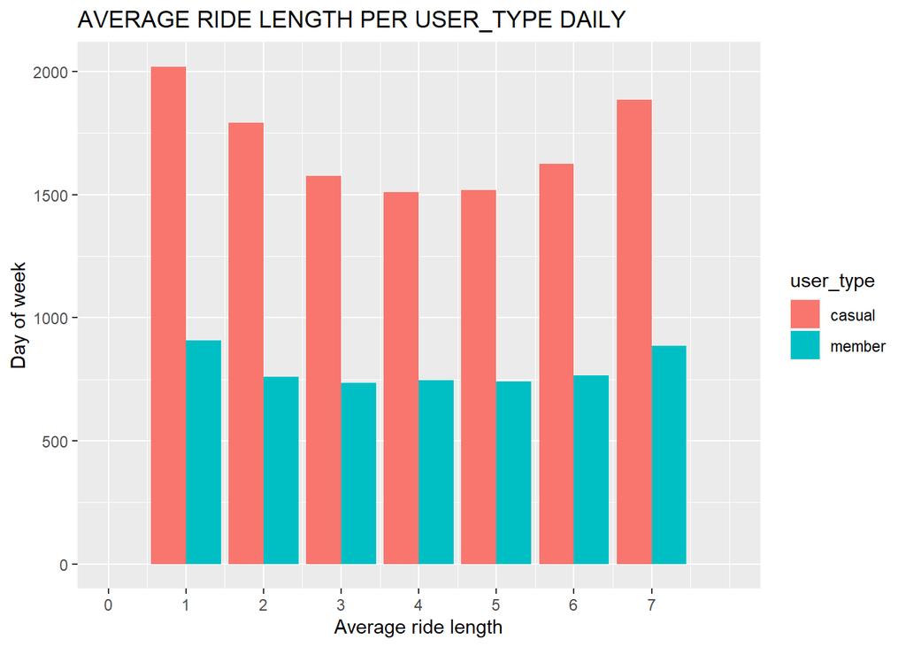

```r
#find average ride_length per user_type per day of week and visualize
all_trips %>%
  group_by(user_type, day_of_week) %>%
  drop_na() %>%
  summarise(average_ride=mean(ride_length)) %>%
  ggplot() + geom_col(aes(x = day_of_week, y = average_ride, fill = user_type), position = "dodge") +
  scale_x_continuous(breaks = seq(0, 7, 1),
                     limits=c(0, 8)) +
  labs(title = "AVERAGE RIDE LENGTH PER USER_TYPE DAILY", x = "Average ride length", y = "Day of week")
```

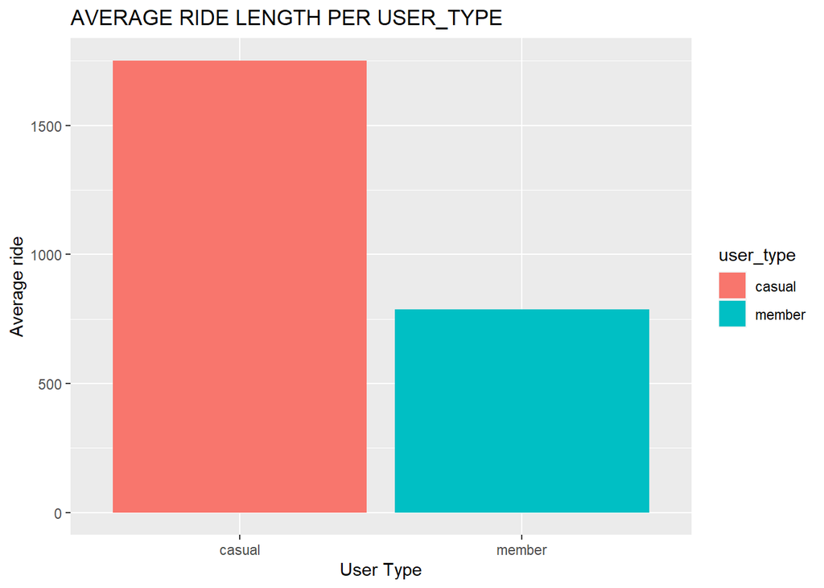

```r
#find the average ride per user_type
all_trips %>%
 group_by(user_type) %>%
  drop_na() %>%
  summarise(average_ride=mean(ride_length)) %>%
  ggplot()+ geom_col(aes(x=user_type, y= average_ride, fill=user_type))+
  labs(title = "AVERAGE RIDE LENGTH PER USER_TYPE ", x = "User Type", y = "Average ride")
```

```r
#find the number of rides per user_type daily
ride_per_day <-all_trips %>%
  count(day_of_week, user_type)
ride_per_day
```

```
## # A tibble: 14 × 3
##    day_of_week user_type      n
##          <dbl> <chr>      <int>
##  1           1 casual    458621
##  2           1 member    350988
##  3           2 casual    271895
##  4           2 member    387835
##  5           3 casual    257087
##  6           3 member    433733
##  7           4 casual    267899
##  8           4 member    450407
##  9           5 casual    275831
## 10           5 member    425298
## 11           6 casual    345784
## 12           6 member    413657
## 13           7 casual    531971
## 14           7 member    405445
```

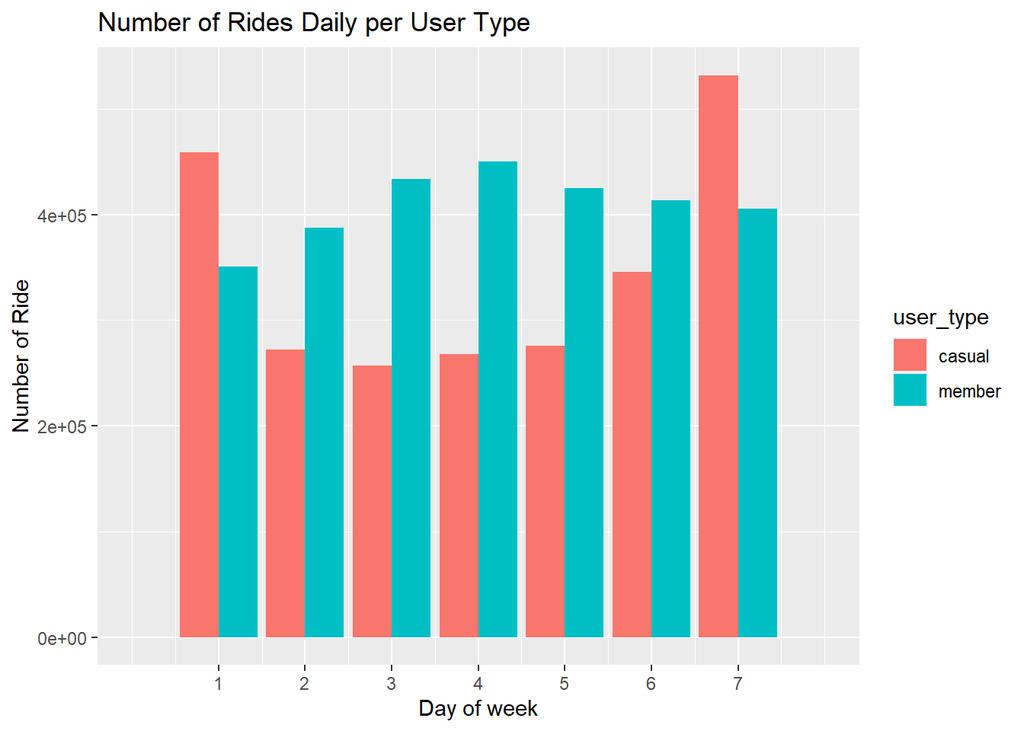

```r
ggplot(data = ride_per_day)+ geom_col(mapping = aes(x=day_of_week, y=n, fill=user_type), position = "dodge")+
  scale_x_continuous(breaks = seq(1, 7, 1),
                     limits=c(0, 8))+
  labs(title = "Number of Rides Daily per User Type", x = "Day of week", y = "Number of Ride")
```

```r
#find the types of bikes mostly preferred by differnt user_type
taste <-all_trips %>%
  count(bike_type, user_type)

taste
```

```
## # A tibble: 6 × 3
##   bike_type     user_type       n
##   <chr>         <chr>       <int>
## 1 classic_bike  casual    1201233
## 2 classic_bike  member    1837945
## 3 docked_bike   casual     291104
## 4 docked_bike   member          1
## 5 electric_bike casual     916751
## 6 electric_bike member    1029417
```

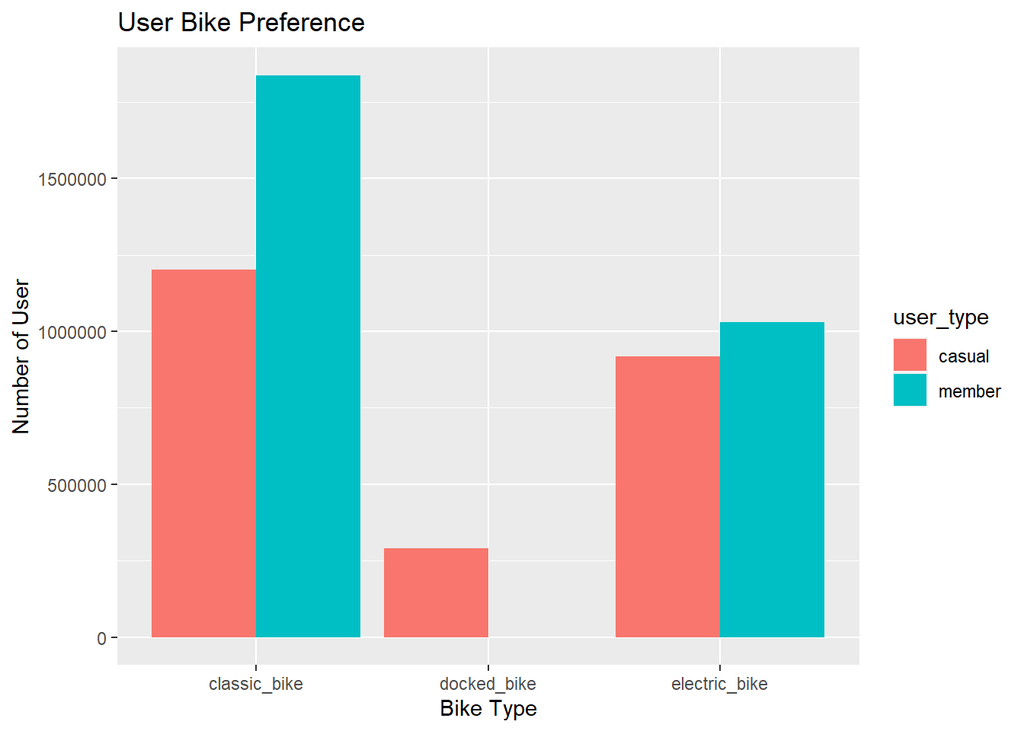

```r
ggplot(data = taste)+ geom_col(mapping = aes(x=bike_type, y=n, fill=user_type), position = "dodge")+
  labs(title = "User Bike Preference", x = "Bike Type", y = "Number of User")
```